# Assignment2

## AKINDELE DAVID AWE - 8999846

### CSCN 8010 - 24F - Sec1to2- Founcdations of Machine Learning Framework

### Professor Ran Feldesh.

```python
import pandas as pd
import numpy as np
import matplotlib.pyplot as plt
import seaborn as sns
from sklearn import datasets
```

### 1. Get the data

```python
#loading the dataset
diabetes_X, diabetes_y = datasets.load_diabetes(return_X_y=True, as_frame=True,scaled=False)
diabetes_df = pd.DataFrame(diabetes_X)


# Displaying the first 5 rows of the dataset
print(diabetes_X.head())
```

```
    age  sex   bmi     bp     s1     s2    s3   s4      s5    s6
0  59.0  2.0  32.1  101.0  157.0   93.2  38.0  4.0  4.8598  87.0
1  48.0  1.0  21.6   87.0  183.0  103.2  70.0  3.0  3.8918  69.0
2  72.0  2.0  30.5   93.0  156.0   93.6  41.0  4.0  4.6728  85.0
3  24.0  1.0  25.3   84.0  198.0  131.4  40.0  5.0  4.8903  89.0
4  50.0  1.0  23.0  101.0  192.0  125.4  52.0  4.0  4.2905  80.0
```

### 2. Framing the problem

The primary objective of analyzing the diabetes dataset is to predict the progression of diabetes in patients based on their health-related features, such as body mass index (BMI), blood pressure, and various serum measurements. This predictive task can be framed as a regression problem where the goal is to estimate a continuous target variable: the level of disease progression one year after baseline measurements.

### 3. Performing Exploratory Data Analysis

```python
# Get basic information about the dataset
diabetes_df.info()

# Summary statistics of the dataset
diabetes_df.describe()
```

```
<class 'pandas.core.frame.DataFrame'>
RangeIndex: 442 entries, 0 to 441
Data columns (total 10 columns):
 #   Column  Non-Null Count  Dtype
---  ------  --------------  -----
 0   age     442 non-null    float64
 1   sex     442 non-null    float64
 2   bmi     442 non-null    float64
 3   bp      442 non-null    float64
 4   s1      442 non-null    float64
 5   s2      442 non-null    float64
 6   s3      442 non-null    float64
 7   s4      442 non-null    float64
 8   s5      442 non-null    float64
 9   s6      442 non-null    float64
dtypes: float64(10)
memory usage: 34.7 KB
```

|  | age | sex | bmi | bp | s1 | s2 | s3 | s4 | s5 | s6 |
| --- | --- | --- | --- | --- | --- | --- | --- | --- | --- | --- |
| count | 442.000000 | 442.000000 | 442.000000 | 442.000000 | 442.000000 | 442.000000 | 442.000000 | 442.000000 | 442.000000 | 442.000000 |
| mean | 48.518100 | 1.468326 | 26.375792 | 94.647014 | 189.140271 | 115.439140 | 49.788462 | 4.070249 | 4.641411 | 91.260181 |
| std | 13.109028 | 0.499561 | 4.418122 | 13.831283 | 34.608052 | 30.413081 | 12.934202 | 1.290450 | 0.522391 | 11.496335 |
| min | 19.000000 | 1.000000 | 18.000000 | 62.000000 | 97.000000 | 41.600000 | 22.000000 | 2.000000 | 3.258100 | 58.000000 |
| 25% | 38.250000 | 1.000000 | 23.200000 | 84.000000 | 164.250000 | 96.050000 | 40.250000 | 3.000000 | 4.276700 | 83.250000 |
| 50% | 50.000000 | 1.000000 | 25.700000 | 93.000000 | 186.000000 | 113.000000 | 48.000000 | 4.000000 | 4.620050 | 91.000000 |
| 75% | 59.000000 | 2.000000 | 29.275000 | 105.000000 | 209.750000 | 134.500000 | 57.750000 | 5.000000 | 4.997200 | 98.000000 |
| max | 79.000000 | 2.000000 | 42.200000 | 133.000000 | 301.000000 | 242.400000 | 99.000000 | 9.090000 | 6.107000 | 124.000000 |

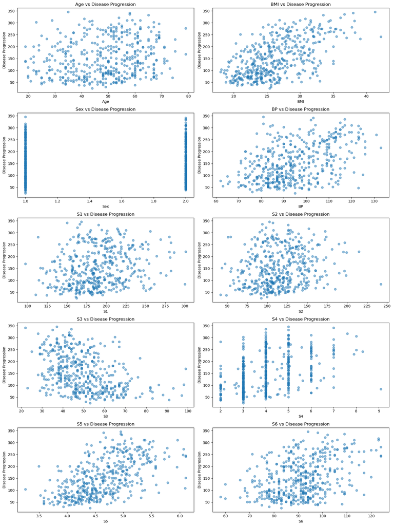

```python
diabetes_df['target'] = diabetes_y

##Visualizing the data
# Scatter plot for all features and target
plt.figure(figsize=(15,20))

# Plot age vs target
plt.subplot(5, 2, 1)
plt.scatter(diabetes_df['age'], diabetes_df['target'], alpha=0.5)
plt.title('Age vs Disease Progression')
plt.xlabel('Age')
plt.ylabel('Disease Progression')

# Plot bmi vs target
plt.subplot(5, 2, 2)
plt.scatter(diabetes_df['bmi'], diabetes_df['target'], alpha=0.5)
plt.title('BMI vs Disease Progression')
plt.xlabel('BMI')
plt.ylabel('Disease Progression')

#Plot sex vs target
plt.subplot(5, 2, 3)
plt.scatter(diabetes_df['sex'], diabetes_df['target'], alpha=0.5)
plt.title('Sex vs Disease Progression')
plt.xlabel('Sex')
plt.ylabel('Disease Progression')

#Plot Bp vs target
plt.subplot(5, 2, 4)
plt.scatter(diabetes_df['bp'], diabetes_df['target'], alpha=0.5)
plt.title('BP vs Disease Progression')
plt.xlabel('BP')
plt.ylabel('Disease Progression')

#Plot s1 vs target
plt.subplot(5, 2, 5)
plt.scatter(diabetes_df['s1'], diabetes_df['target'], alpha=0.5)
plt.title('S1 vs Disease Progression')
plt.xlabel('S1')
plt.ylabel('Disease Progression')

#Plot s2 vs target
plt.subplot(5, 2, 6)
plt.scatter(diabetes_df['s2'], diabetes_df['target'], alpha=0.5)
plt.title('S2 vs Disease Progression')
plt.xlabel('S2')
plt.ylabel('Disease Progression')

#Plot s3 vs target
plt.subplot(5, 2, 7)
plt.scatter(diabetes_df['s3'], diabetes_df['target'], alpha=0.5)
plt.title('S3 vs Disease Progression')
plt.xlabel('S3')
plt.ylabel('Disease Progression')

#Plot s4 vs target
plt.subplot(5, 2, 8)
plt.scatter(diabetes_df['s4'], diabetes_df['target'], alpha=0.5)
plt.title('S4 vs Disease Progression')
plt.xlabel('S4')
plt.ylabel('Disease Progression')

#Plot s5 vs target
plt.subplot(5, 2, 9)
plt.scatter(diabetes_df['s5'], diabetes_df['target'], alpha=0.5)
plt.title('S5 vs Disease Progression')
plt.xlabel('S5')
plt.ylabel('Disease Progression')

#Plot s6 vs target
plt.subplot(5, 2, 10)
plt.scatter(diabetes_df['s6'], diabetes_df['target'], alpha=0.5)
plt.title('S6 vs Disease Progression')
plt.xlabel('S6')
plt.ylabel('Disease Progression')

plt.tight_layout()
plt.show()
```

#### Scatter Plot insights

Age vs. Disease Progression: \ Insight: The scatter plot may show little or no clear trend between age and disease progression. In many cases, age might not have a strong linear relationship with disease progression because the condition may depend more on lifestyle or biological markers than age alone. \ BMI (Body Mass Index) vs. Disease Progression: \ Insight: This feature may show a positive relationship with the target variable. As BMI increases, disease progression could also increase. This makes sense as higher BMI is often associated with conditions like diabetes, especially Type 2 diabetes, which is related to weight and metabolism. \ Sex vs. Disease Progression: \ Insight: If sex is included as a binary feature, the scatter plot might not reveal much about the relationship between gender and disease progression, but this could indicate that diabetes progression affects individuals similarly regardless of gender. \ BP (Blood Pressure) vs. Disease Progression: \ Insight: Blood pressure could show a moderate or weak positive correlation with disease progression. Higher blood pressure might correlate with more advanced stages of diabetes or complications related to it. \ S1, S2, S3, S4, S5, S6 (Blood Serum Measurements) vs. Disease Progression: \ Insight: These features represent certain blood serum measurements. One of them, S5, shows a stronger positive correlation with disease progression as it reflects a biochemical feature that could be directly linked to the progression of diabetes. The others might show weaker relationships depending on how directly they impact the target.

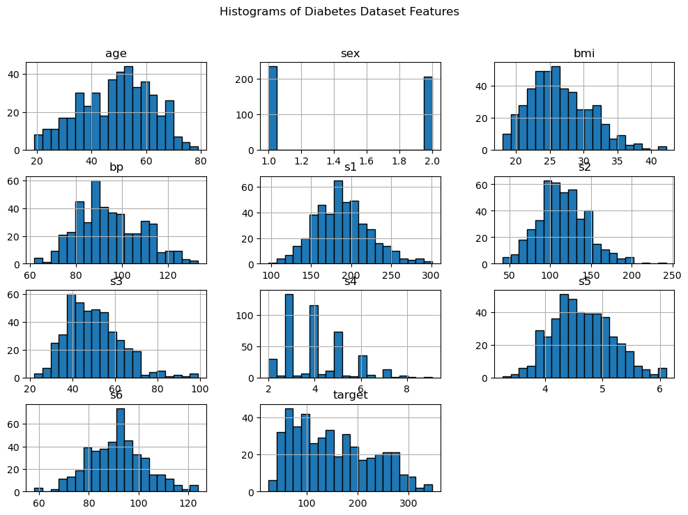

```python
# Plotting histograms for all features
diabetes_df.hist(figsize=(12, 8), bins=20, edgecolor='black')
plt.suptitle("Histograms of Diabetes Dataset Features")
plt.show()
```

#### Histogram insights

Normal vs. Skewed Distributions: Features like BMI, S5, or bp might have skewed distributions, while others like age might be more uniformly or normally distributed. Skewed features could indicate that certain values (like high BMI) are rare but important.

Outliers: Outliers can be observed in some histograms, particularly in blood serum measurements or BMI. These outliers represent individuals who may have extreme health conditions and could significantly influence the disease progression.

Symmetry and Spread: Histograms that are symmetrical (like those of normally distributed variables) show that most values are centered around the mean, while those with wide spreads suggest high variability in that feature.

```python
# Calculate the correlation matrix
correlation_matrix = diabetes_df.corr()
correlation_matrix
```

|  | age | sex | bmi | bp | s1 | s2 | s3 | s4 | s5 | s6 | target |
| --- | --- | --- | --- | --- | --- | --- | --- | --- | --- | --- | --- |
| age | 1.000000 | 0.173737 | 0.185085 | 0.335428 | 0.260061 | 0.219243 | -0.075181 | 0.203841 | 0.270774 | 0.301731 | 0.187889 |
| sex | 0.173737 | 1.000000 | 0.088161 | 0.241010 | 0.035277 | 0.142637 | -0.379090 | 0.332115 | 0.149916 | 0.208133 | 0.043062 |
| bmi | 0.185085 | 0.088161 | 1.000000 | 0.395411 | 0.249777 | 0.261170 | -0.366811 | 0.413807 | 0.446157 | 0.388680 | 0.586450 |
| bp | 0.335428 | 0.241010 | 0.395411 | 1.000000 | 0.242464 | 0.185548 | -0.178762 | 0.257650 | 0.393480 | 0.390430 | 0.441482 |
| s1 | 0.260061 | 0.035277 | 0.249777 | 0.242464 | 1.000000 | 0.896663 | 0.051519 | 0.542207 | 0.515503 | 0.325717 | 0.212022 |
| s2 | 0.219243 | 0.142637 | 0.261170 | 0.185548 | 0.896663 | 1.000000 | -0.196455 | 0.659817 | 0.318357 | 0.290600 | 0.174054 |
| s3 | -0.075181 | -0.379090 | -0.366811 | -0.178762 | 0.051519 | -0.196455 | 1.000000 | -0.738493 | -0.398577 | -0.273697 | -0.394789 |
| s4 | 0.203841 | 0.332115 | 0.413807 | 0.257650 | 0.542207 | 0.659817 | -0.738493 | 1.000000 | 0.617859 | 0.417212 | 0.430453 |
| s5 | 0.270774 | 0.149916 | 0.446157 | 0.393480 | 0.515503 | 0.318357 | -0.398577 | 0.617859 | 1.000000 | 0.464669 | 0.565883 |
| s6 | 0.301731 | 0.208133 | 0.388680 | 0.390430 | 0.325717 | 0.290600 | -0.273697 | 0.417212 | 0.464669 | 1.000000 | 0.382483 |
| target | 0.187889 | 0.043062 | 0.586450 | 0.441482 | 0.212022 | 0.174054 | -0.394789 | 0.430453 | 0.565883 | 0.382483 | 1.000000 |

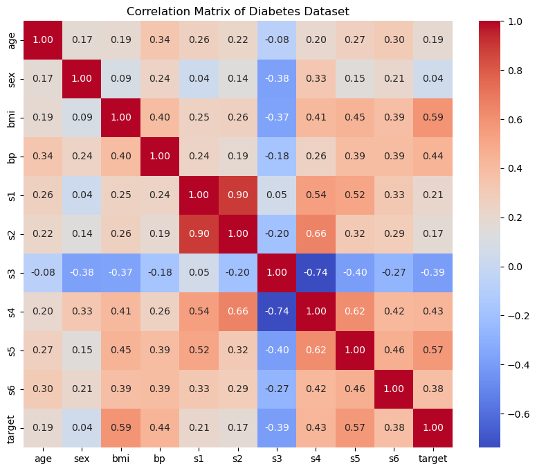

```python
# Create a heatmap for better visualization
plt.figure(figsize=(10, 8))
sns.heatmap(correlation_matrix, annot=True, cmap='coolwarm', fmt=".2f")
plt.title('Correlation Matrix of Diabetes Dataset')
plt.show()
```

#### Correlation matrix insights

BMI and S5 are likely to have the strongest positive correlations with the target variable (disease progression). This suggests that these features are strong predictors and should be prioritized when building predictive models.

Blood pressure and other serum markers (S1, S2, S3, S4, S6) may show weaker correlations with disease progression, indicating they are less predictive on their own but could still contribute value in combination with other features.

Age may show a weak correlation with disease progression, meaning it may not be as important as some of the biological markers

### 4. Clean the data if needed, and explain your reasoning for your reader

In real-world medical data, some outliers (e.g., extremely high BMI or blood pressure) may represent rare but valid cases of disease. Removing them could result in loss of critical information, especially when modeling diseases like diabetes, which may affect individuals differently.

Reason not to clean: In medical datasets, outliers often represent extreme cases of a disease and can be essential for understanding the full spectrum of disease progression. Removing outliers might bias the analysis or reduce the model's ability to generalize to patients with severe conditions.

### 5. Split the dataset to a train (75%) and validation set (10%), and test set (15%).

```python
from sklearn.model_selection import train_test_split

# Splitting the dataset into 75% train and 25% remaining (validation + test)
train_data, remaining_data = train_test_split(diabetes_df, test_size=0.25, random_state=42)

# Splitting the remaining 25% into 10% validation and 15% test
# The 25% remaining_data is divided into validation and test (40% of 25% = 10%, 60% of 25% = 15%)
validation_data, test_data = train_test_split(remaining_data, test_size=0.6, random_state=42)

# Checking the size of each split
print("Train set size:", len(train_data))
print("Validation set size:", len(validation_data))
print("Test set size:", len(test_data))
```

```
Train set size: 331
Validation set size: 44
Test set size: 67
```

### Part 2

1. Models: a univariate polynomial regression on the BMI feature versus the "disease progression one year after baseline" - from degree 0 to 5 (6 models)
2. Compare the models using the training and validation data. Construct a table summarizing the train validation results. Each model should have a separate row in the table:
   1. R-Squared
   2. Mean Absolute Error (MAE)
   3. MAPE

```python
from sklearn.preprocessing import PolynomialFeatures
from sklearn.linear_model import LinearRegression
from sklearn.metrics import r2_score, mean_absolute_error

# Selecting features and target variable
X_train = train_data[['bmi']]
y_train = train_data['target']
X_val = validation_data[['bmi']]
y_val = validation_data['target']

# Preparing a table to hold the results
results = pd.DataFrame(columns=['Degree', 'Train R-Squared', 'Train MAE', 'Train MAPE', 'Validation R-Squared', 'Validation MAE', 'Validation MAPE'])

# Training polynomial regression models from degree 0 to 5
for degree in range(6):
    # Create polynomial features
    poly = PolynomialFeatures(degree=degree)
    X_poly_train = poly.fit_transform(X_train)
    X_poly_val = poly.transform(X_val)

    # Training the model
    model = LinearRegression()
    model.fit(X_poly_train, y_train)

    # Make predictions
    y_train_pred = model.predict(X_poly_train)
    y_val_pred = model.predict(X_poly_val)

    # Calculating evaluation metrics for training data
    train_r_squared = r2_score(y_train, y_train_pred)
    train_mae = mean_absolute_error(y_train, y_train_pred)
    train_mape = np.mean(np.abs((y_train - y_train_pred) / y_train)) * 100  # Mean Absolute Percentage Error

    # Calculating evaluation metrics for validation data
    val_r_squared = r2_score(y_val, y_val_pred)
    val_mae = mean_absolute_error(y_val, y_val_pred)
    val_mape = np.mean(np.abs((y_val - y_val_pred) / y_val)) * 100  # Mean Absolute Percentage Error

    # Storing the results in the table
    results = results.append({
        'Degree': degree,
        'Train R-Squared': train_r_squared,
        'Train MAE': train_mae,
        'Train MAPE': train_mape,
        'Validation R-Squared': val_r_squared,
        'Validation MAE': val_mae,
        'Validation MAPE': val_mape
    }, ignore_index=True)

# Displaying our results
results
```

[output not shown]

|  | Degree | Train R-Squared | Train MAE | Train MAPE | Validation R-Squared | Validation MAE | Validation MAPE |
| --- | --- | --- | --- | --- | --- | --- | --- |
| 0 | 0.0 | 0.000000 | 66.201641 | 62.826669 | -0.106957 | 66.057059 | 71.263880 |
| 1 | 1.0 | 0.349672 | 52.287739 | 48.362886 | 0.331264 | 47.208472 | 47.060009 |
| 2 | 2.0 | 0.350764 | 52.207314 | 48.298534 | 0.331631 | 47.213700 | 47.239667 |
| 3 | 3.0 | 0.350774 | 52.198968 | 48.280744 | 0.331638 | 47.185414 | 47.222673 |
| 4 | 4.0 | 0.353014 | 52.092653 | 48.053266 | 0.340758 | 46.090118 | 46.050330 |
| 5 | 5.0 | 0.354100 | 52.059191 | 48.004021 | 0.349881 | 45.462121 | 45.175275 |

### 8. Identify the best model based on the table above.

Conclusion:

Based on the provided metrics, Degree 5 appears to be the best model. It has the highest R-Squared, indicating a good fit to the validation data, and reasonable MAE and MAPE values.

### 9. Run the chosen model on the test set and provide results (R-Squared, MAPE, MAE) (1 point).

```python
# Selecting features and target variable
X_test = test_data[['bmi']]
y_test = test_data['target']

# Training the polynomial regression model of degree 5
degree = 5
poly = PolynomialFeatures(degree=degree)
X_poly_train = poly.fit_transform(X_train)
X_poly_val = poly.transform(X_val)
X_poly_test = poly.transform(X_test)

# Training the model
model = LinearRegression()
model.fit(X_poly_train, y_train)

# Make predictions on the test set
y_test_pred = model.predict(X_poly_test)

# Calculating evaluation metrics for the test set
test_r_squared = r2_score(y_test, y_test_pred)
test_mae = mean_absolute_error(y_test, y_test_pred)
test_mape = np.mean(np.abs((y_test - y_test_pred) / y_test)) * 100  # Mean Absolute Percentage Error

# Displaying the results
print("Test Set Results:")
print("R-Squared:", test_r_squared)
print("Mean Absolute Error (MAE):", test_mae)
print("Mean Absolute Percentage Error (MAPE):", test_mape)
```

```
Test Set Results:
R-Squared: 0.2666965782925853
Mean Absolute Error (MAE): 51.75025699093537
Mean Absolute Percentage Error (MAPE): 43.02671287096847
```

### 10. Plot a graph of the train, validation and test data points, and the fit of the chosen model over each of them (1 point).

```
c:\Users\Akindele Awe David\anaconda3\Lib\site-packages\sklearn\base.py:439: UserWarning: X does not have valid feature names, but PolynomialFeatures was fitted with feature names
  warnings.warn(
```

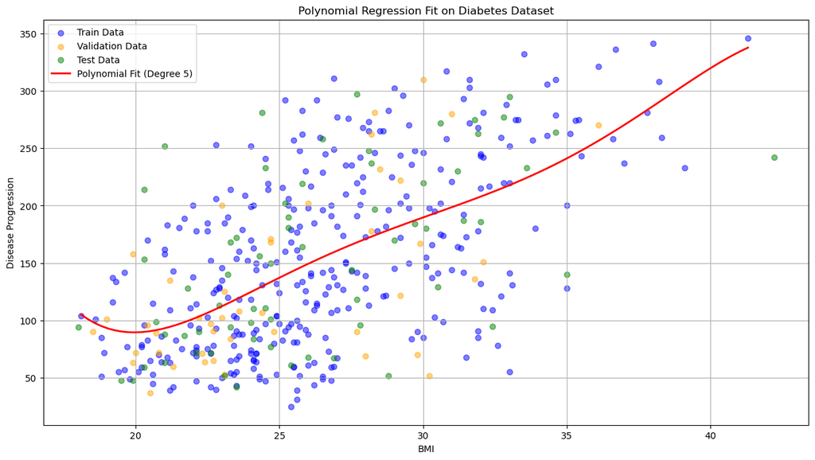

```python
# Creating a range of values for plotting the polynomial regression curve
X_range = np.linspace(X_train['bmi'].min(), X_train['bmi'].max(), 100).reshape(-1, 1)
X_poly_range = poly.transform(X_range)
y_range = model.predict(X_poly_range)

# Plotting the graph
plt.figure(figsize=(15, 8))

# Train data points
plt.scatter(X_train, y_train, color='blue', label='Train Data', alpha=0.5)

# Validation data points
plt.scatter(X_val, y_val, color='orange', label='Validation Data', alpha=0.5)

# Test data points
plt.scatter(X_test, y_test, color='green', label='Test Data', alpha=0.5)

# Plotting the polynomial regression fit
plt.plot(X_range, y_range, color='red', label='Polynomial Fit (Degree 5)', linewidth=2)

# Creating our Labels and Title
plt.title('Polynomial Regression Fit on Diabetes Dataset')
plt.xlabel('BMI')
plt.ylabel('Disease Progression')
plt.legend()
plt.grid()
plt.show()
```

### 11. Write down the equation of the best model (with a two decimal digit precision, assuming it's sufficient)

```python
# Retrieving the coefficients and intercept
intercept = model.intercept_

# Retrieving the coefficients and intercept
coefficients = model.coef_

# Initializing the equation with the intercept
Equation = f"y = {intercept:.2f}"

# Loop through coefficients to build the equation
for i in range(1, len(coefficients)):
    Equation += f" + ({coefficients[i]:.2f} * x^{i})"

# Print the chosen model equation
print('Chosen model equation:')
print(Equation)
```

```
Chosen model equation:
y = 10409.75 + (-1809.22 * x^1) + (123.57 * x^2) + (-4.12 * x^3) + (0.07 * x^4) + (-0.00 * x^5)
```

### 12. Calculate the expected diabetes progression for a BMI value of your choice using `model.predict()` for that value (0.5 point).

```python
# we calculate the expected diabetes progression for a random BMI value e.g 35
bmi_value = 35

# Transforming the BMI value into a 2D array and create polynomial features
bmi_array = np.array([[bmi_value]])
bmi_poly = poly.transform(bmi_array)

# Predicting the diabetes progression for the chosen BMI value
predicted_progression = model.predict(bmi_poly)

# Print out the expected diabetes progression
print(f'Expected diabetes progression for a BMI of {bmi_value}: {predicted_progression[0]:.2f}')
```

```
Expected diabetes progression for a BMI of 35: 241.16
```

```
c:\Users\Akindele Awe David\anaconda3\Lib\site-packages\sklearn\base.py:439: UserWarning: X does not have valid feature names, but PolynomialFeatures was fitted with feature names
  warnings.warn(
```

### 13. How many trainable parameters are we fitting for each of the models? Explain these values. One way is to use sklearn function `get_feature_names_out()`(1 point)

```python
# Selecting the feature (BMI) and target variable (disease progression)
X = diabetes_df[['bmi']]
y = diabetes_df['target']

# Creating a list to hold the number of parameters for each degree
parameters_count = []

# Calculating the number of parameters for degrees 0 to 5
for degree in range(6):
    poly = PolynomialFeatures(degree=degree)
    poly.fit(X)  # Fit polynomial features
    # Get the feature names and count them
    feature_names = poly.get_feature_names_out()
    num_parameters = len(feature_names)  # Total number of features (parameters)
    parameters_count.append((degree, num_parameters))

# Creating a DataFrame for better readability
params_df = pd.DataFrame(parameters_count, columns=['Degree', 'Number of Parameters'])
params_df
```

|  | Degree | Number of Parameters |
| --- | --- | --- |
| 0 | 0 | 1 |
| 1 | 1 | 2 |
| 2 | 2 | 3 |
| 3 | 3 | 4 |
| 4 | 4 | 5 |
| 5 | 5 | 6 |

### 14. Provide a conclusion section. In particular, do a deep dive on where the model fails, and add a short section in the conclusions that describes the model limitations. This should be in addition to summarizing it performance. (1 point).

Based on the provided evaluation metrics, the polynomial regression model with a degree of 5 appears to be the best-performing model for predicting in the diabetes dataset. It exhibits the highest validation R-Squared (0.349881), indicating a relatively strong fit to the validation data. Additionally, its validation MAE (45.462121) and MAPE (45.175275) are among the lowest, suggesting reasonable prediction accuracy.

Model Limitations:

While the degree 5 model demonstrates good performance, it's important to acknowledge its limitations:

Overfitting: Polynomial regression models with higher degrees can be prone to overfitting, especially when dealing with limited datasets. Overfitting occurs when the model becomes too complex and fits the training data too closely, potentially leading to poor generalization to new data.

Non-linearity: The assumption of a polynomial relationship between the features and the target variable may not always hold true in real-world scenarios. If the underlying relationship is highly non-linear, a polynomial model might not capture it accurately.

Sensitivity to Outliers: The presence of outliers in the dataset can disproportionately influence the fitted polynomial regression model, particularly in higher-degree models. This sensitivity can lead to inaccurate predictions for individuals represented by extreme values in BMI, skewing the overall performance metrics and misrepresenting the model's accuracy.

In conclusion, while the degree 5 polynomial regression model provides a promising approach to predicting diabetes progression based on BMI, it is essential to be aware of its limitations. Further research and development could focus on incorporating additional features, exploring alternative modeling techniques, and addressing the potential issues of overfitting and outliers to improve predictive accuracy and robustness.

### Part 3: In this part, use all features in the dataset, or drop some features per your discretion based on the EDA.

Repeat the steps in part 2 for the following models: \

```
1. Two polynomial models (degrees >1, of your choice) \
2. Two decision trees (e.g. consider changing the `max_depth` hyperparameter) \
3. Two kNNs
```

```python
# Selecting features (using all features)
X_train = train_data.drop('target', axis=1)  # All features except target
y_train = train_data['target']
X_val = validation_data.drop('target', axis=1)  # All features except target
y_val = validation_data['target']
X_test = test_data.drop('target', axis=1)  # All features except target
y_test = test_data['target']

# Preparing a list to hold results for all models
model_results = pd.DataFrame(columns=['Model', 'R-Squared', 'MAE', 'MAPE'])

# Training two polynomial regression models of degree 7 and degree 8
for degree in [7, 8]:
    # Create polynomial features
    poly = PolynomialFeatures(degree=degree)

    # Transforming the features
    X_poly_train = poly.fit_transform(X_train)
    X_poly_val = poly.transform(X_val)
    X_poly_test = poly.transform(X_test)

    # Training the model
    model = LinearRegression()
    model.fit(X_poly_train, y_train)

    # Make predictions
    y_train_pred = model.predict(X_poly_train)
    y_val_pred = model.predict(X_poly_val)
    y_test_pred = model.predict(X_poly_test)

    # Calculating evaluation metrics for validation data
    val_r_squared = r2_score(y_val, y_val_pred)
    val_mae = mean_absolute_error(y_val, y_val_pred)
    val_mape = np.mean(np.abs((y_val - y_val_pred) / y_val)) * 100  # MAPE

    # Storing the results in the DataFrame
    model_results = model_results.append({
        'Model': f'Polynomial Regression (Degree={degree})',
        'R-Squared': val_r_squared,
        'MAE': val_mae,
        'MAPE': val_mape
    }, ignore_index=True)



# Training two Decision Trees with different max_depth values
from sklearn.tree import DecisionTreeRegressor

for max_depth in [3, 5]:  #using depths 3 and 5
    tree_model = DecisionTreeRegressor(max_depth=max_depth)
    tree_model.fit(X_train, y_train)

    # Make predictions
    y_train_pred = tree_model.predict(X_train)
    y_val_pred = tree_model.predict(X_val)
    y_test_pred = tree_model.predict(X_test)

    # Calculating evaluation metrics for validation data
    val_r_squared = r2_score(y_val, y_val_pred)
    val_mae = mean_absolute_error(y_val, y_val_pred)
    val_mape = np.mean(np.abs((y_val - y_val_pred) / y_val)) * 100  # MAPE

    # Storing the results in the DataFrame
    model_results = model_results.append({
        'Model': f'Decision Tree (max_depth={max_depth})',
        'R-Squared': val_r_squared,
        'MAE': val_mae,
        'MAPE': val_mape
    }, ignore_index=True)


# Training two kNN models with different number of neighbors
from sklearn.neighbors import KNeighborsRegressor

for n_neighbors in [2, 4]:  # Using 2 and 4 nearest neighbors
    knn_model = KNeighborsRegressor(n_neighbors=n_neighbors)
    knn_model.fit(X_train, y_train)

    # Make predictions
    y_train_pred = knn_model.predict(X_train)
    y_val_pred = knn_model.predict(X_val)
    y_test_pred = knn_model.predict(X_test)

    # Calculating evaluation metrics for validation data
    val_r_squared = r2_score(y_val, y_val_pred)
    val_mae = mean_absolute_error(y_val, y_val_pred)
    val_mape = np.mean(np.abs((y_val - y_val_pred) / y_val)) * 100  # MAPE

    # Storing the results in the DataFrame
    model_results = model_results.append({
        'Model': f'kNN (n_neighbors={n_neighbors})',
        'R-Squared': val_r_squared,
        'MAE': val_mae,
        'MAPE': val_mape
    }, ignore_index=True)

# Displaying the combined results
print("Model Performance Results:")
model_results
```

```
C:\Users\Akindele Awe David\AppData\Local\Temp\ipykernel_18448\642617493.py:37: FutureWarning: The frame.append method is deprecated and will be removed from pandas in a future version. Use pandas.concat instead.
  model_results = model_results.append({
```

```
Model Performance Results:
```

[output not shown]

|  | Model | R-Squared | MAE | MAPE |
| --- | --- | --- | --- | --- |
| 0 | Polynomial Regression (Degree=7) | -1931.781971 | 949.192556 | 729.452467 |
| 1 | Polynomial Regression (Degree=8) | -3729.609246 | 1247.582486 | 942.294148 |
| 2 | Decision Tree (max_depth=3) | 0.198306 | 48.126248 | 47.672897 |
| 3 | Decision Tree (max_depth=5) | 0.082455 | 50.077301 | 48.414506 |
| 4 | kNN (n_neighbors=2) | -0.497869 | 68.693182 | 65.112235 |
| 5 | kNN (n_neighbors=4) | 0.021432 | 55.857955 | 52.678730 |

Model Comparison:

Best Model:

Based on the provided metrics, the Decision Tree (max_depth=3) appears to be the best-performing model. It has a positive R-Squared value, indicating a reasonable fit to the data, and relatively low MAE and MAPE, suggesting good prediction accuracy.